# CMSC320 Final Project

# Univeristy of Maryland Computer Science Course Grade Predictor

## Team: Siddhesh Gupta, Tanmay Prakash, Shanil Kothari

## Introduction

Computer Science is a popular major at University of Maryland - College Park and as students of Computer Science our goal was to help other students by providing a tool to predict their performance in some of the courses. Students always wonder what grade they could get in their upper level courses and choose accordingly. Students also want to know how much work is required for a class or how difficult will a class be for them.

This is why we wanted to build a model which predict which upper level computer science courses can a student take and do reasonably well on them based on their performances in previous courses (Pre-Requisites or Gateway Courses). We want to answer the question that are grades and performance in a course correlated to the performance in the pre-requisite courses for that course?

If our model is reasonabaly successful, we can provide insights to students which can prove very helpful when taking some important decisions. For example, a student can know that historically other students who have a similar performance to them have ended with a X grade in the class. So student can understand and know that they might have to put in more work than usual to earn a better grade than this. And sometimes its just peace of mind and anxiety buster to know where you stand and where you can end-up at the end of the semester. The model can help predict the courses where a student can perform the best so they can make an informed decision which can impact their progress as a student at the university.

## Data Collection

Since a student's academic records are private and is enforced by laws like FERPA (Family Educational Rights and Privacy Act). FERPA is a federal law that protects a student's education records. It may only disclose a student's educational record if he or she has given written consent to do so. We requested for anonymized data from the University of Maryland, but due to these laws we could not gain access to the data. Therefore we had to do it the harder way - survey people for their data. For this we made a Google form to collect grades for each Computer Science course students took. The form was anonymous so that no personal information is collected and can be linked to a specific student.

```python
import pandas as pd
import numpy as np
import seaborn as sns
import matplotlib.pyplot as plt
plt.rcParams["figure.figsize"] = (14,5)
import warnings
warnings.filterwarnings("ignore")
```

### Initial Data Cleaning

We perform basic cleaning on the survey data so that we can visualize and perform exploratory data analysis.

```python
df = pd.read_csv("data.csv")
```

```python
for i, row in df.iterrows():
    txt = "User{0}"
    df['Timestamp'][i] = txt.format(i)

df.columns=["Users", "CMSC131", "CMSC132", "CMSC216", "CMSC250", "CMSC330", "CMSC351", "MATH140", "MATH141", "MATH240", "MATH241",
              "STAT400", "CS_Track", "CMSC4XX", "CMSC411", "CMSC412", "CMSC414", "CMSC416", "CMSC417", "CMSC420", "CMSC421",
              "CMSC422", "CMSC423", "CMSC424", "CMSC426", "CMSC427", "CMSC470", "CMSC430", "CMSC433", "CMSC434", "CMSC435", "CMSC436",
              "CMSC451", "CMSC452", "CMSC454", "CMSC456", "CMSC457", "CMSC460", "CMSC466", "CMSC320", "CMSC425", "CMSC472",
              "CMSC473", "CMSC474", "CMSC475", "Graduated"]
```

```python
df = df.replace("Don't want to share", "Not Attempted")
```

```python
df[df.columns[1:11]] = df[df.columns[1:11]].replace("Not Attempted", np.nan)
df[df.columns[14:45]] = df[df.columns[14:45]].replace("Not Attempted", np.nan)
```

```python
df.head()
```

|  | Users | CMSC131 | CMSC132 | CMSC216 | CMSC250 | CMSC330 | CMSC351 | MATH140 | MATH141 | MATH240 | ... | CMSC457 | CMSC460 | CMSC466 | CMSC320 | CMSC425 | CMSC472 | CMSC473 | CMSC474 | CMSC475 | Graduated |
| --- | --- | --- | --- | --- | --- | --- | --- | --- | --- | --- | --- | --- | --- | --- | --- | --- | --- | --- | --- | --- | --- |
| 0 | User0 | A | A | A | A | A | B- | A | A | A | ... | NaN | NaN | NaN | A | NaN | NaN | NaN | NaN | NaN | Not Completed |
| 1 | User1 | A | A- | A- | A | A | A+ | A | A | NaN | ... | NaN | NaN | NaN | NaN | NaN | NaN | NaN | NaN | NaN | NaN |
| 2 | User2 | B | B- | B | C+ | A | A | A | A | A | ... | NaN | NaN | NaN | B- | NaN | NaN | NaN | NaN | NaN | Not Completed |
| 3 | User3 | A | B+ | B- | B | B+ | C- | NaN | NaN | B | ... | NaN | NaN | NaN | NaN | NaN | NaN | NaN | NaN | NaN | Not Completed |
| 4 | User4 | A | A | A- | A | A- | A+ | A | A+ | A- | ... | NaN | NaN | NaN | A | NaN | NaN | NaN | NaN | NaN | Not Completed |

5 rows × 46 columns

## Exploratory Data Analysis

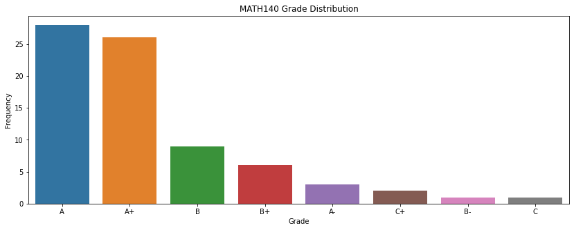

[figure not shown]

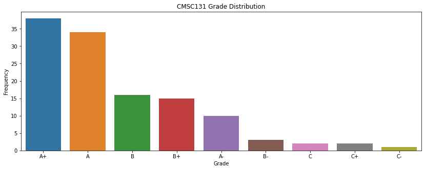

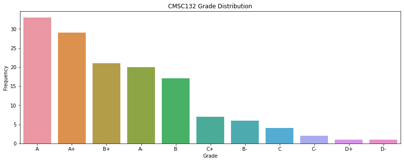

```python
MATH140 = df['MATH140'].value_counts()
sns.barplot(MATH140.index, MATH140.values)
plt.title("MATH140 Grade Distribution")
plt.xlabel("Grade")
plt.ylabel("Frequency")
plt.show()
MATH141 = df['MATH141'].value_counts()
sns.barplot(MATH141.index, MATH141.values)
plt.title("MATH140 Grade Distribution")
plt.xlabel("Grade")
plt.ylabel("Frequency")
plt.show()
CMSC131 = df['CMSC131'].value_counts()
sns.barplot(CMSC131.index, CMSC131.values)
plt.title("CMSC131 Grade Distribution")
plt.xlabel("Grade")
plt.ylabel("Frequency")
plt.show()
CMSC132 = df['CMSC132'].value_counts()
sns.barplot(CMSC132.index, CMSC132.values)
plt.title("CMSC132 Grade Distribution")
plt.xlabel("Grade")
plt.ylabel("Frequency")
plt.show()
```

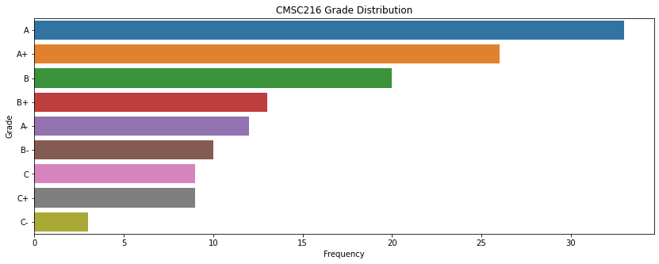

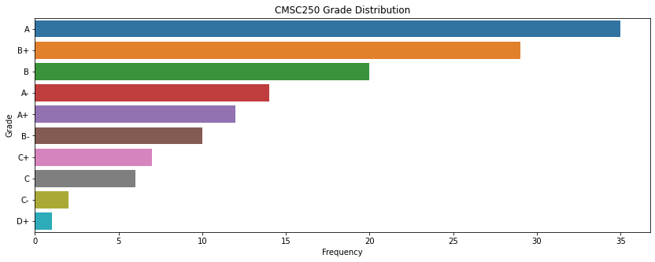

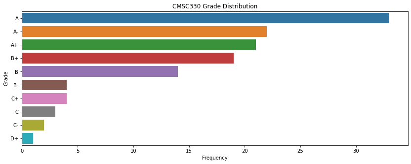

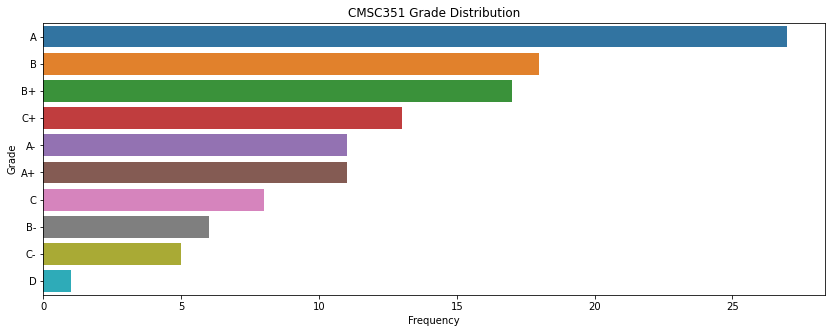

```python
# CMSC216
CMSC216 = df['CMSC216'].value_counts()
sns.barplot(CMSC216.values, CMSC216.index)
plt.title("CMSC216 Grade Distribution")
plt.xlabel("Frequency")
plt.ylabel("Grade")
plt.show()
# CMSC250
CMSC250 = df['CMSC250'].value_counts()
sns.barplot(CMSC250.values, CMSC250.index)
plt.title("CMSC250 Grade Distribution")
plt.xlabel("Frequency")
plt.ylabel("Grade")
plt.show()
# CMSC330
CMSC330 = df['CMSC330'].value_counts()
sns.barplot(CMSC330.values, CMSC330.index)
plt.title("CMSC330 Grade Distribution")
plt.xlabel("Frequency")
plt.ylabel("Grade")
plt.show()
# CMSC351
CMSC351 = df['CMSC351'].value_counts()
sns.barplot(CMSC351.values, CMSC351.index)
plt.title("CMSC351 Grade Distribution")
plt.xlabel("Frequency")
plt.ylabel("Grade")
plt.show()
```

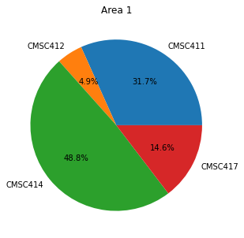

```python
# AREA 1
CMSC411_num = df['CMSC411'].notna().sum()
CMSC412_num = df['CMSC412'].notna().sum()
CMSC414_num = df['CMSC414'].notna().sum()
CMSC417_num = df['CMSC417'].notna().sum()

data = [CMSC411_num, CMSC412_num, CMSC414_num, CMSC417_num]
labels = 'CMSC411', 'CMSC412', 'CMSC414', 'CMSC417'
plt.pie(data,labels=labels,autopct='%1.1f%%')
plt.title("Area 1")
plt.show()
```

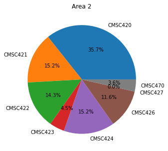

```python
# AREA 2
CMSC420_num = df['CMSC420'].notna().sum()
CMSC421_num = df['CMSC421'].notna().sum()
CMSC422_num = df['CMSC422'].notna().sum()
CMSC423_num = df['CMSC423'].notna().sum()
CMSC424_num = df['CMSC424'].notna().sum()
CMSC426_num = df['CMSC426'].notna().sum()
CMSC427_num = df['CMSC427'].notna().sum()
CMSC470_num = df['CMSC470'].notna().sum()
data = [CMSC420_num, CMSC421_num, CMSC422_num, CMSC423_num, CMSC424_num, CMSC426_num, CMSC427_num, CMSC470_num]
labels = 'CMSC420', 'CMSC421', 'CMSC422', 'CMSC423', 'CMSC424', 'CMSC426', 'CMSC427', 'CMSC470'
plt.pie(data,labels=labels,autopct='%1.1f%%')
plt.title("Area 2")
plt.show()
```

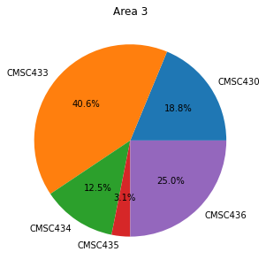

```python
# AREA 3
CMSC430_num = df['CMSC430'].notna().sum()
CMSC433_num = df['CMSC433'].notna().sum()
CMSC434_num = df['CMSC434'].notna().sum()
CMSC435_num = df['CMSC435'].notna().sum()
CMSC436_num = df['CMSC436'].notna().sum()
data = [CMSC430_num, CMSC433_num, CMSC434_num, CMSC435_num, CMSC436_num]
labels = 'CMSC430', 'CMSC433', 'CMSC434', 'CMSC435', 'CMSC436'
plt.pie(data,labels=labels,autopct='%1.1f%%')
plt.title("Area 3")
plt.show()
```

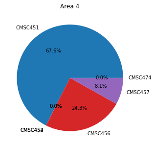

```python
# AREA 4
CMSC451_num = df['CMSC451'].notna().sum()
CMSC452_num = df['CMSC452'].notna().sum()
CMSC454_num = df['CMSC454'].notna().sum()
CMSC456_num = df['CMSC456'].notna().sum()
CMSC457_num = df['CMSC457'].notna().sum()
CMSC474_num = df['CMSC474'].notna().sum()
data = [CMSC451_num, CMSC452_num, CMSC454_num, CMSC456_num, CMSC457_num, CMSC474_num]
labels = 'CMSC451', 'CMSC452', 'CMSC454', 'CMSC456', 'CMSC457', 'CMSC474'
plt.pie(data,labels=labels,autopct='%1.1f%%')
plt.title("Area 4")
plt.show()
```

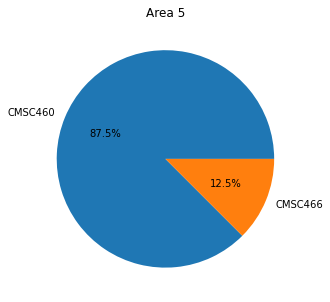

```python
# AREA 5
CMSC460_num = df['CMSC460'].notna().sum()
CMSC466_num = df['CMSC466'].notna().sum()
data = [CMSC460_num, CMSC466_num]
labels = 'CMSC460', 'CMSC466'
plt.pie(data,labels=labels,autopct='%1.1f%%')
plt.title("Area 5")
plt.show()
```

[figure not shown]

```python
# UPPER LEVEL ELECTIVES
CMSC320_num = df['CMSC320'].notna().sum()
CMSC425_num = df['CMSC425'].notna().sum()
CMSC472_num = df['CMSC472'].notna().sum()
CMSC473_num = df['CMSC473'].notna().sum()
CMSC475_num = df['CMSC475'].notna().sum()
data = [CMSC420_num, CMSC425_num, CMSC472_num, CMSC473_num, CMSC475_num]
labels = 'CMSC320', 'CMSC425', 'CMSC472','CMSC473', 'CMSC475'
plt.pie(data,labels=labels,autopct='%1.1f%%')
plt.title("Upper Level Electives")
plt.show()
```

## Data Pre-Processing

To prepare the data for training the model we need perform some data cleaning. We start by creating a function to replace the not attempted values for the pre-requisite courses and gateway requirements as these can be skipped in a number of ways by AP's, high school credits or by recieving credit by exam. So we create two dataframes for the computer science courses where we set the not attempted values to A and B. We do the same for compulsory mathematics courses.

Then we define the upper level computer science courses in a different dataframe so we can merge it easily. Then there are 3 functions for merging the dataframes, dropping the plus and minus signs from grades and enconding the grades as numbers. We decided to drop the plus and minus signs from grades as it would make complicated for the model to train on so many different possible values and as we did not have many rows of data for each grade. We then encode the A as 4, B as 3, C as 2, D as 1, and F / Not Attempted / Don't want to share as 0.

We then use a different approach for the MATH24x courses as by degree requirements, only one MATH24x course is required and many computer science chose to take either. So we decided to merge the grades into one column and take the higher grade if available. If the person has not attempted either, then we take the average of their MATH140 and MATH141 grades and drop it by one grade as MATH24x are more difficult compared to MATH14x courses.

Finally, a clean version of the dataframe is ready to be used in the Machine Learning model.

```python
def replace_not_attempted(df, grade):
    return df.replace('Not Attempted', grade)
```

```python
df2 = df[["Users", "CMSC131", "CMSC132", "CMSC216", "CMSC250"]]
df_cs_A = replace_not_attempted(df2, 'A')
df_cs_B = replace_not_attempted(df2, 'B')
```

```python
df3 = df[["Users", "MATH140", "MATH141", "STAT400"]]
df_math_A = replace_not_attempted(df3, 'A')
df_math_B = replace_not_attempted(df3, 'B')
```

We define a dataframe with just upper level cs courses

```python
df_upper = df[["Users", "CMSC330", "CMSC351", "CMSC411", "CMSC412", "CMSC414", "CMSC416", "CMSC417", "CMSC420", "CMSC421",
              "CMSC422", "CMSC423", "CMSC424", "CMSC426", "CMSC427", "CMSC470", "CMSC430", "CMSC433", "CMSC434", "CMSC435", "CMSC436",
              "CMSC451", "CMSC452", "CMSC454", "CMSC456", "CMSC457", "CMSC460", "CMSC466", "CMSC320", "CMSC425", "CMSC472",
              "CMSC473", "CMSC474", "CMSC475"]]
```

Merger: Function to combine the datasets created, this makes it easier to combine datasets if we decide to chose a different assumed grade for the CMSC or MATH courses.

Plus_minus_clean: Changes all +/- to just the letter grade.

Encoding_help: Encoding the letters A as 4, B as 3, C as 2, D as 1, and F / Not Attempted / Don't want to share as 0.

```python
def merger(df, df_cs, df_math, df_upper):
    df = df[["Users", "CS_Track", "CMSC4XX", "Graduated"]]
    df_temp = df.merge(df_math, on = "Users")
    df_temp = df_temp.merge(df_cs, on = "Users")
    return df_temp.merge(df_upper, on = "Users")

def plus_minus_clean(df):
    df_temp = df.replace(["A-", "A+"], "A")
    df_temp = df_temp.replace(["B-", "B+"], "B")
    df_temp = df_temp.replace(["C-", "C+"], "C")
    df_temp = df_temp.replace(["D-", "D+"], "D")
    return df_temp

def encoding_help(df):
    df_temp = df.replace("A", 4)
    df_temp = df_temp.replace("B", 3)
    df_temp = df_temp.replace("C", 2)
    df_temp = df_temp.replace("D", 1)
    df_temp = df_temp.replace([np.nan, "F"], 0)
    return df_temp
```

```python
df4 = merger(df, df_cs_A, df_math_A, df_upper)
df5 = plus_minus_clean(df4)
df6 = encoding_help(df5)
```

For MATH240/MATH241, we create a new column with MATH24x, then clean the plus minus values and encode the letter grades. After which we decided to use the better grade from either of the course if both are attempted, if both are not then just the one which is attempted. If none are attempted then we take the average of MATH140 and MATH141 and then drop it by one grade because the MATH24x courses are harder than the MATH14x courses. Then we just add the column to to the main dataframe.

```python
df_m24x = df[["MATH240", "MATH241"]]
df_m24x["MATH24x"] = np.nan
df_m24x = encoding_help(plus_minus_clean(df_m24x))
```

```python
for i in range(df_m24x.shape[0]):
    if(df_m24x.iat[i, 0] > df_m24x.iat[i, 1]):
        df_m24x.iat[i, 2] = df_m24x.iat[i, 0]
    elif(df_m24x.iat[i, 0] < df_m24x.iat[i, 1]):
        df_m24x.iat[i, 2] = df_m24x.iat[i, 1]
    elif(df_m24x.iat[i, 0] == 0):
        df_m24x.iat[i, 2] = df6.iloc[i, 4:6].mean() - 1
    elif(df_m24x.iat[i, 0] == df_m24x.iat[i, 1]):
        df_m24x.iat[i, 2] = df_m24x.iat[i, 0]

df_m24x["MATH24x"] = df_m24x["MATH24x"].astype(int)
```

```python
df6.insert(6, "MATH24x", df_m24x["MATH24x"])
```

```python
df6.head()
```

|  | Users | CS_Track | CMSC4XX | Graduated | MATH140 | MATH141 | MATH24x | STAT400 | CMSC131 | CMSC132 | ... | CMSC456 | CMSC457 | CMSC460 | CMSC466 | CMSC320 | CMSC425 | CMSC472 | CMSC473 | CMSC474 | CMSC475 |
| --- | --- | --- | --- | --- | --- | --- | --- | --- | --- | --- | --- | --- | --- | --- | --- | --- | --- | --- | --- | --- | --- |
| 0 | User0 | General | Yes | Not Completed | 4.0 | 4.0 | 4 | 4 | 4.0 | 4.0 | ... | 0.0 | 0.0 | 0.0 | 0.0 | 4.0 | 0.0 | 0.0 | 0.0 | 0.0 | 0.0 |
| 1 | User1 | General | No | 0 | 4.0 | 4.0 | 3 | 4 | 4.0 | 4.0 | ... | 0.0 | 0.0 | 0.0 | 0.0 | 0.0 | 0.0 | 0.0 | 0.0 | 0.0 | 0.0 |
| 2 | User2 | General | Yes | Not Completed | 4.0 | 4.0 | 4 | 3 | 3.0 | 3.0 | ... | 0.0 | 0.0 | 0.0 | 0.0 | 3.0 | 0.0 | 0.0 | 0.0 | 0.0 | 0.0 |
| 3 | User3 | Data Science | Yes | Not Completed | 0.0 | 0.0 | 3 | 3 | 4.0 | 3.0 | ... | 0.0 | 0.0 | 0.0 | 0.0 | 0.0 | 0.0 | 0.0 | 0.0 | 0.0 | 0.0 |
| 4 | User4 | General | Yes | Not Completed | 4.0 | 4.0 | 4 | 4 | 4.0 | 4.0 | ... | 0.0 | 0.0 | 0.0 | 0.0 | 4.0 | 0.0 | 0.0 | 0.0 | 0.0 | 0.0 |

5 rows × 45 columns

```python
df_ul = df6[["Users", "CMSC4XX", "CMSC330", "CMSC351", "CMSC411", "CMSC412", "CMSC414", "CMSC416", "CMSC417", "CMSC420", "CMSC421",
              "CMSC422", "CMSC423", "CMSC424", "CMSC426", "CMSC427", "CMSC470", "CMSC430", "CMSC433", "CMSC434", "CMSC435", "CMSC436",
              "CMSC451", "CMSC452", "CMSC454", "CMSC456", "CMSC457", "CMSC460", "CMSC466", "CMSC320", "CMSC425", "CMSC472", "CMSC473", "CMSC474", "CMSC475"]]

df_ul.head()
```

|  | Users | CMSC4XX | CMSC330 | CMSC351 | CMSC411 | CMSC412 | CMSC414 | CMSC416 | CMSC417 | CMSC420 | ... | CMSC456 | CMSC457 | CMSC460 | CMSC466 | CMSC320 | CMSC425 | CMSC472 | CMSC473 | CMSC474 | CMSC475 |
| --- | --- | --- | --- | --- | --- | --- | --- | --- | --- | --- | --- | --- | --- | --- | --- | --- | --- | --- | --- | --- | --- |
| 0 | User0 | Yes | 4.0 | 3.0 | 0.0 | 0.0 | 0.0 | 0.0 | 0.0 | 4.0 | ... | 0.0 | 0.0 | 0.0 | 0.0 | 4.0 | 0.0 | 0.0 | 0.0 | 0.0 | 0.0 |
| 1 | User1 | No | 4.0 | 4.0 | 0.0 | 0.0 | 0.0 | 0.0 | 0.0 | 0.0 | ... | 0.0 | 0.0 | 0.0 | 0.0 | 0.0 | 0.0 | 0.0 | 0.0 | 0.0 | 0.0 |
| 2 | User2 | Yes | 4.0 | 4.0 | 0.0 | 0.0 | 0.0 | 0.0 | 0.0 | 4.0 | ... | 0.0 | 0.0 | 0.0 | 0.0 | 3.0 | 0.0 | 0.0 | 0.0 | 0.0 | 0.0 |
| 3 | User3 | Yes | 3.0 | 2.0 | 0.0 | 0.0 | 0.0 | 0.0 | 0.0 | 0.0 | ... | 0.0 | 0.0 | 0.0 | 0.0 | 0.0 | 0.0 | 0.0 | 0.0 | 0.0 | 0.0 |
| 4 | User4 | Yes | 4.0 | 4.0 | 0.0 | 0.0 | 0.0 | 0.0 | 0.0 | 0.0 | ... | 0.0 | 0.0 | 0.0 | 0.0 | 4.0 | 0.0 | 0.0 | 0.0 | 0.0 | 0.0 |

5 rows × 35 columns

## Machine Learning

After EDA Exploratory Data Analysis, we see that we good amount of data for CMSC 330 and CMSC 351. (Approximately 100 enteries). For CMSC 4xx courses we don't have much data to build a successful model for individual courses.

We first cleaned and refined the data further to weed out the the enteries which were not complete. These were enteries where students didn't complete the courses.

```python
df_x = df6[df6['CMSC4XX'] == "Yes"]
df_x.drop(["CMSC351", "CMSC330", "CMSC411", "CMSC412", "CMSC414", "CMSC416", "CMSC417", "CMSC420", "CMSC421",
           "CMSC422", "CMSC423", "CMSC424", "CMSC426", "CMSC427", "CMSC470", "CMSC430", "CMSC433", "CMSC434", "CMSC435", "CMSC436",
           "CMSC451", "CMSC452", "CMSC454", "CMSC456", "CMSC457", "CMSC460", "CMSC466", "CMSC320", "CMSC425", "CMSC472",
           "CMSC473", "CMSC474", "CMSC475"], inplace=True, axis=1)
df_x
```

|  | Users | CS_Track | CMSC4XX | Graduated | MATH140 | MATH141 | MATH24x | STAT400 | CMSC131 | CMSC132 | CMSC216 | CMSC250 |
| --- | --- | --- | --- | --- | --- | --- | --- | --- | --- | --- | --- | --- |
| 0 | User0 | General | Yes | Not Completed | 4.0 | 4.0 | 4 | 4 | 4.0 | 4.0 | 4.0 | 4.0 |
| 2 | User2 | General | Yes | Not Completed | 4.0 | 4.0 | 4 | 3 | 3.0 | 3.0 | 3.0 | 2.0 |
| 3 | User3 | Data Science | Yes | Not Completed | 0.0 | 0.0 | 3 | 3 | 4.0 | 3.0 | 3.0 | 3.0 |
| 4 | User4 | General | Yes | Not Completed | 4.0 | 4.0 | 4 | 4 | 4.0 | 4.0 | 4.0 | 4.0 |
| 5 | User5 | General | Yes | Graduated | 4.0 | 4.0 | 4 | 4 | 4.0 | 4.0 | 4.0 | 4.0 |
| ... | ... | ... | ... | ... | ... | ... | ... | ... | ... | ... | ... | ... |
| 155 | User155 | Machine Learning | Yes | Not Completed | 4.0 | 4.0 | 4 | 4 | 4.0 | 4.0 | 4.0 | 3.0 |
| 159 | User159 | General | Yes | Not Completed | 0.0 | 0.0 | 3 | 4 | 0.0 | 3.0 | 2.0 | 2.0 |
| 161 | User161 | General | Yes | Not Completed | 0.0 | 0.0 | -1 | 4 | 0.0 | 0.0 | 0.0 | 0.0 |
| 162 | User162 | Machine Learning | Yes | Not Completed | 4.0 | 4.0 | 4 | 4 | 3.0 | 3.0 | 3.0 | 4.0 |
| 163 | User163 | General | Yes | Not Completed | 4.0 | 4.0 | 4 | 3 | 4.0 | 4.0 | 4.0 | 4.0 |

95 rows × 12 columns

### One-Hot Encoding

Next step is to do one hot encoding. Its the process of converting the categorical variables into numerical representations. The model can't understand the grade values A, B, C, D and so on.

Categorical data refers to variables that are made up of label values, for example, a “color” variable could have the values “red“, “blue, and “green”. Think of values like different categories that sometimes have a natural ordering to them.

One hot encoding is one method of converting data to prepare it for an algorithm and get a better prediction. With one-hot, we convert each categorical value into a new categorical column and assign a binary value of 1 or 0 to those columns. Each integer value is represented as a binary vector. All the values are zero, and the index is marked with a 1.

You can refer to this guide to learn and understand more about One Hot Encoding - https://www.educative.io/blog/one-hot-encoding

So we change all the grades to 0s and 1s. So the feature transforms from grade in x course to true(1) or false(0). For example A in Math 140 changes to Math 140(C) = 0 Math 140(B) = 0 Math 140(A) = 1.

After doing this process we get 25 features to train the model on from the initial 8.

One thing you need to be carefull of while doing this step is multicollienearity issue. This arrises when 2 or more predictors in the model are highly correlated to one another. If we input both true and false values into the model, we will have multicollinearity issue. To avoid this we only input one out of the True or False variables. This is popularly known as Dummy Variable Trap.

This guide explains this process and this issue in detail Categorical Encoding in Machine Learning.

To make this process less tedious, I have written a function to do this for us. We just call the function and input the column names for which we have to this process.

```python
# One Hot Encoding of the variables

def one_hot_encoding(column_names, df):
  for column in column_names:
    df[column] = df[column].astype(int)
    tempdf = pd.get_dummies(df[column], prefix=column)
    tempdf.drop(tempdf.columns[0], inplace=True, axis=1)
    df = pd.merge(
        left=df,
        right=tempdf,
        left_index=True,
        right_index=True,
    )
    df = df.drop(columns=column)

  return df

df_x = one_hot_encoding(['MATH140', 'MATH141', 'MATH24x', 'STAT400', 'CMSC131', 'CMSC132',
                  'CMSC216', 'CMSC250'], df_x)

df_x.drop(['Users', 'CS_Track', 'CMSC4XX', 'Graduated', 'MATH24x_0'], inplace=True, axis=1)
df_x
```

|  | MATH140_2 | MATH140_3 | MATH140_4 | MATH141_2 | MATH141_3 | MATH141_4 | MATH24x_2 | MATH24x_3 | MATH24x_4 | STAT400_3 | ... | CMSC132_2 | CMSC132_3 | CMSC132_4 | CMSC216_2 | CMSC216_3 | CMSC216_4 | CMSC250_1 | CMSC250_2 | CMSC250_3 | CMSC250_4 |
| --- | --- | --- | --- | --- | --- | --- | --- | --- | --- | --- | --- | --- | --- | --- | --- | --- | --- | --- | --- | --- | --- |
| 0 | 0 | 0 | 1 | 0 | 0 | 1 | 0 | 0 | 1 | 0 | ... | 0 | 0 | 1 | 0 | 0 | 1 | 0 | 0 | 0 | 1 |
| 2 | 0 | 0 | 1 | 0 | 0 | 1 | 0 | 0 | 1 | 1 | ... | 0 | 1 | 0 | 0 | 1 | 0 | 0 | 1 | 0 | 0 |
| 3 | 0 | 0 | 0 | 0 | 0 | 0 | 0 | 1 | 0 | 1 | ... | 0 | 1 | 0 | 0 | 1 | 0 | 0 | 0 | 1 | 0 |
| 4 | 0 | 0 | 1 | 0 | 0 | 1 | 0 | 0 | 1 | 0 | ... | 0 | 0 | 1 | 0 | 0 | 1 | 0 | 0 | 0 | 1 |
| 5 | 0 | 0 | 1 | 0 | 0 | 1 | 0 | 0 | 1 | 0 | ... | 0 | 0 | 1 | 0 | 0 | 1 | 0 | 0 | 0 | 1 |
| ... | ... | ... | ... | ... | ... | ... | ... | ... | ... | ... | ... | ... | ... | ... | ... | ... | ... | ... | ... | ... | ... |
| 155 | 0 | 0 | 1 | 0 | 0 | 1 | 0 | 0 | 1 | 0 | ... | 0 | 0 | 1 | 0 | 0 | 1 | 0 | 0 | 1 | 0 |
| 159 | 0 | 0 | 0 | 0 | 0 | 0 | 0 | 1 | 0 | 0 | ... | 0 | 1 | 0 | 1 | 0 | 0 | 0 | 1 | 0 | 0 |
| 161 | 0 | 0 | 0 | 0 | 0 | 0 | 0 | 0 | 0 | 0 | ... | 0 | 0 | 0 | 0 | 0 | 0 | 0 | 0 | 0 | 0 |
| 162 | 0 | 0 | 1 | 0 | 0 | 1 | 0 | 0 | 1 | 0 | ... | 0 | 1 | 0 | 0 | 1 | 0 | 0 | 0 | 0 | 1 |
| 163 | 0 | 0 | 1 | 0 | 0 | 1 | 0 | 0 | 1 | 1 | ... | 0 | 0 | 1 | 0 | 0 | 1 | 0 | 0 | 0 | 1 |

95 rows × 25 columns

```python
df_y = df_ul[df_ul['CMSC4XX'] == "Yes"]
y_351 = df_y['CMSC351'].astype(int)
y_330 = df_y['CMSC330'].astype(int)
y_351
```

```
0      3
2      4
3      2
4      4
5      4
      ..
155    3
159    3
161    3
162    4
163    4
Name: CMSC351, Length: 95, dtype: int32
```

### Model Building

Now finally we are ready to build the model. We first use a module called train_test_split found in sklearn.model_selection. This helps us to shuffle and separate our data into train and test. This is important to calculate the performance of the model later on.

Model_selection is a method for setting a blueprint to analyze data and then using it to measure new data. Selecting a proper model allows you to generate accurate results when making a prediction.

We use training data to train the model. After the model is trained, we test the model on unseen data to evaluate the performance of the model. This helps us understand how are model will perform if we are to use this model to predict the grades in real-life.

Now our problem is a multi-class classification problem. We already know what binary classification is - When we have to classify something into one of two categories (0 or 1). But we need classify the data into different grades (A, B, C, D, F). For this we need to multi-classification (for classification into more than 2 groups).

For multi-classification we can use many of the same algorithms that we learned and did for binary classification with slight modifications. Multi-class classification makes the assumption that each sample is assigned to one and only one label: a fruit can be either an apple or a pear but not both at the same time.

```python
from sklearn import linear_model as lm
from sklearn.model_selection import train_test_split
from sklearn import metrics
from sklearn.metrics import accuracy_score,recall_score,precision_score,f1_score
from sklearn import svm
from sklearn import tree
from sklearn import ensemble
from sklearn.neural_network import MLPClassifier
from sklearn.multiclass import OneVsRestClassifier
from sklearn.pipeline import make_pipeline
from sklearn.preprocessing import StandardScaler
from sklearn.svm import LinearSVC

def printer(y_test, y_pred, model_name):
    # Model Evaluation metrics
    print("This is the metrics for ", model_name)
    print(metrics.classification_report(y_test, y_pred))
    print('Accuracy Score : ' + str(accuracy_score(y_test, y_pred)))
    print()

random_state = 42
```

### CMSC330 Model

```
This is the metrics for  Logistic Regression
              precision    recall  f1-score   support

           2       0.00      0.00      0.00         0
           3       0.75      0.43      0.55         7
           4       0.79      0.92      0.85        12

    accuracy                           0.74        19
   macro avg       0.51      0.45      0.46        19
weighted avg       0.77      0.74      0.74        19

Accuracy Score : 0.7368421052631579

This is the metrics for  Decision Tree Regression
              precision    recall  f1-score   support

           0       0.00      0.00      0.00         0
           2       0.00      0.00      0.00         0
           3       0.75      0.43      0.55         7
           4       0.83      0.83      0.83        12

    accuracy                           0.68        19
   macro avg       0.40      0.32      0.34        19
weighted avg       0.80      0.68      0.73        19

Accuracy Score : 0.6842105263157895

This is the metrics for  Neural Network
              precision    recall  f1-score   support

           2       0.00      0.00      0.00         0
           3       0.60      0.43      0.50         7
           4       0.83      0.83      0.83        12

    accuracy                           0.68        19
   macro avg       0.48      0.42      0.44        19
weighted avg       0.75      0.68      0.71        19

Accuracy Score : 0.6842105263157895
```

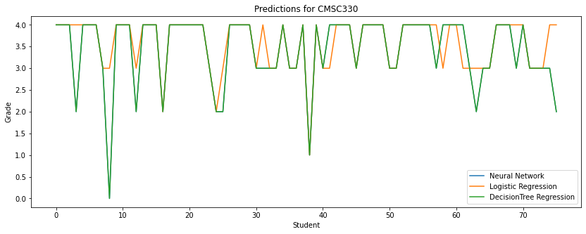

```python
x_train, x_test, y_train, y_test = train_test_split(df_x, y_330, test_size=0.2, random_state=random_state)

model_1 = lm.LogisticRegression(multi_class='ovr')
model_2 = tree.DecisionTreeClassifier()
model_3 = MLPClassifier(solver='lbfgs')

model_1.fit(x_train, y_train)
model_2.fit(x_train, y_train)
model_3.fit(x_train, y_train)

printer(y_test, model_1.predict(x_test), "Logistic Regression")
printer(y_test, model_2.predict(x_test), "Decision Tree Regression")
printer(y_test, model_3.predict(x_test), "Neural Network")

plt.plot(model_3.predict(x_train), label = "Neural Network")
plt.plot(model_1.predict(x_train), label = "Logistic Regression")
plt.plot(model_2.predict(x_train), label = "DecisionTree Regression")

plt.xlabel('Student')
plt.ylabel('Grade')
plt.title('Predictions for CMSC330')
plt.legend()
```

### Model Evaluation

Precision- It is a measure of the ability of a classification model to identify only the relevant data points.

Recall - It is a measure of the ability of a model to find all the relevant cases within a dataset.

### CMSC351 Model

```
This is the metrics for  Logistic Regression
              precision    recall  f1-score   support

           2       0.20      0.50      0.29         2
           3       1.00      0.20      0.33        10
           4       0.42      0.71      0.53         7

    accuracy                           0.42        19
   macro avg       0.54      0.47      0.38        19
weighted avg       0.70      0.42      0.40        19

Accuracy Score : 0.42105263157894735

This is the metrics for  Decision Tree Regression
              precision    recall  f1-score   support

           0       0.00      0.00      0.00         0
           2       0.00      0.00      0.00         2
           3       0.33      0.20      0.25        10
           4       0.38      0.43      0.40         7

    accuracy                           0.26        19
   macro avg       0.18      0.16      0.16        19
weighted avg       0.31      0.26      0.28        19

Accuracy Score : 0.2631578947368421

This is the metrics for  Neural Network
              precision    recall  f1-score   support

           0       0.00      0.00      0.00         0
           2       0.00      0.00      0.00         2
           3       0.67      0.40      0.50        10
           4       0.33      0.43      0.38         7

    accuracy                           0.37        19
   macro avg       0.25      0.21      0.22        19
weighted avg       0.47      0.37      0.40        19

Accuracy Score : 0.3684210526315789
```

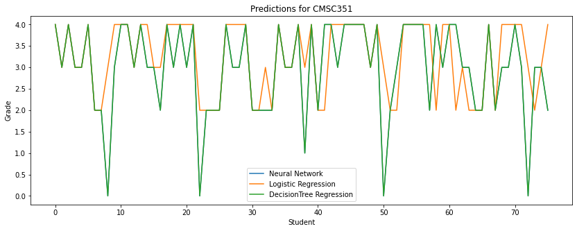

```python
random_state = np.random.RandomState(0)

x_train, x_test, y_train, y_test = train_test_split(df_x, y_351, test_size=0.2, random_state=42)

model_11 = lm.LogisticRegression(multi_class='ovr')
model_22 = tree.DecisionTreeClassifier()
model_33 = MLPClassifier(solver='lbfgs')

model_11.fit(x_train, y_train)
model_22.fit(x_train, y_train)
model_33.fit(x_train, y_train)

printer(y_test, model_11.predict(x_test), "Logistic Regression")
printer(y_test, model_22.predict(x_test), "Decision Tree Regression")
printer(y_test, model_33.predict(x_test), "Neural Network")

plt.plot(model_33.predict(x_train), label = "Neural Network")
plt.plot(model_11.predict(x_train), label = "Logistic Regression")
plt.plot(model_22.predict(x_train), label = "DecisionTree Regression")

plt.xlabel('Student')
plt.ylabel('Grade')
plt.title('Predictions for CMSC351')
plt.legend()
```

Let's test the model with previously un-seen data.

A student can enter grades for the following courses - MATH140, MATH141, MATH24x, STAT400, CMSC131, CMSC132, CMSC216, and CMSC250. Based on these grades the model can predict the grades for the student in the next CS courses the student wants to take.

A CS student voluntereed to test out his grades. The student earned the following grades -

1. MATH140 - A
2. MATH141 - A
3. MATH24X - A
4. STAT400 - B
5. CMSC131 - A
6. CMSC132 - B
7. CMSC216 - B
8. CMSC250 - A

The student recieved following grades in CMSC330 and CMSC351 -

1. CMSC330 - A
2. CMSC351 - B

Now let's enter these grades into the model that we build and let us see what is the result.

```python
grades = ["A", "A", "A", "B", "A", "B", "B", "A"]

def model_test(grades):
  grade_point = []
  for i in range(len(grades)):
    if grades[i] == "A":
      grade_point.append(4)
    elif grades[i] == "B":
      grade_point.append(3)
    elif grades[i] == "C":
      grade_point.append(2)
    elif grades[i] == "D":
      grade_point.append(1)
    else:
      grade_point.append(0)

  zeroes_and_ones = []
  for i in range(0, 8):
    if i == 7 or i == 5:
      if grade_point[i] == 4:
        zeroes_and_ones.insert(0, 0)
        zeroes_and_ones.insert(0, 0)
        zeroes_and_ones.insert(0, 0)
        zeroes_and_ones.insert(0, 1)
      elif grade_point[i] == 3:
        zeroes_and_ones.insert(0, 0)
        zeroes_and_ones.insert(0, 0)
        zeroes_and_ones.insert(0, 1)
        zeroes_and_ones.insert(0, 0)
      elif grade_point[i] == 2:
        zeroes_and_ones.insert(0, 0)
        zeroes_and_ones.insert(0, 1)
        zeroes_and_ones.insert(0, 0)
        zeroes_and_ones.insert(0, 0)
      elif grade_point[i] == 1:
        zeroes_and_ones.insert(0, 1)
        zeroes_and_ones.insert(0, 0)
        zeroes_and_ones.insert(0, 0)
        zeroes_and_ones.insert(0, 0)
    elif i <= 2 or i == 6 or i == 4:
      if grade_point[i] == 4:
        zeroes_and_ones.insert(0, 0)
        zeroes_and_ones.insert(0, 0)
        zeroes_and_ones.insert(0, 1)
      elif grade_point[i] == 3:
        zeroes_and_ones.insert(0, 0)
        zeroes_and_ones.insert(0, 1)
        zeroes_and_ones.insert(0, 0)
      elif grade_point[i] == 2:
        zeroes_and_ones.insert(0, 1)
        zeroes_and_ones.insert(0, 0)
        zeroes_and_ones.insert(0, 0)
    elif i == 3:
      if grade_point[i] == 4:
        zeroes_and_ones.insert(0, 0)
        zeroes_and_ones.insert(0, 1)
      elif grade_point[i] == 3:
        zeroes_and_ones.insert(0, 1)
        zeroes_and_ones.insert(0, 0)


  point = np.array(zeroes_and_ones)
  point = point.reshape(1, -1)
  print(point)

  grade_point_330 = model_2.predict_proba(point)  # Gives output as 3
  grade_point_351 = model_22.predict_proba(point) # Gives output as 3

  print("Therefore the predicted grade of the student in 330 is ", "A", grade_point_330, "with approximately 0.99 probability")
  print("Therefore the predicted grade of the student in 351 is ", "C", grade_point_351, "with approximately 0.99 probability")

model_test(grades)
```

[output not shown]

### Further Improvements

We saw that the data was imbalanced. We had lot of data enteries for students who recieved grades of A. This might be because students felt not safe sharing their grade data openly. It can also be the case that students inflate their grades while entering in the survey.

All these result in a skewed dataset.

We can improve this imbalance by adding more samples from under-represented classes.

To do this we can use the technique of SMOTE - Synthetic Minority Over-sampling Technique. SMOTE technique consists of synthesizing elements for the minority class based on those that already exist. It works by randomly picking a point from the minority class and computing the k-nearest neighbors for this point. The synthetic points are added between the choosen point and its neighbours. You can read about this from [Multi-Class Classification for Imbalanced Dataset](https://towardsdatascience.com/machine-learning-multiclass-classification-with-imbalanced-data-set-29f6a177c1a)

We can also improve the results by having a wider and a more representative dataset.